# Explore Loan Data from Prosper

### Of the features you investigated, were there any unusual distributions? Did you perform any operations on the data to tidy, adjust, or change the form of the data? If so, why did you do this?

- Most of these exploratory histogram plots used default settings
- However, for a few metrics, such as StatedMonthlyIncome, I adjusted the histogram bin size and limited the x-axis values in order to better view the trend

## Bivariate Exploration

Do we see any correlation between features in the dataset? The following visualizations will help us answer this question.

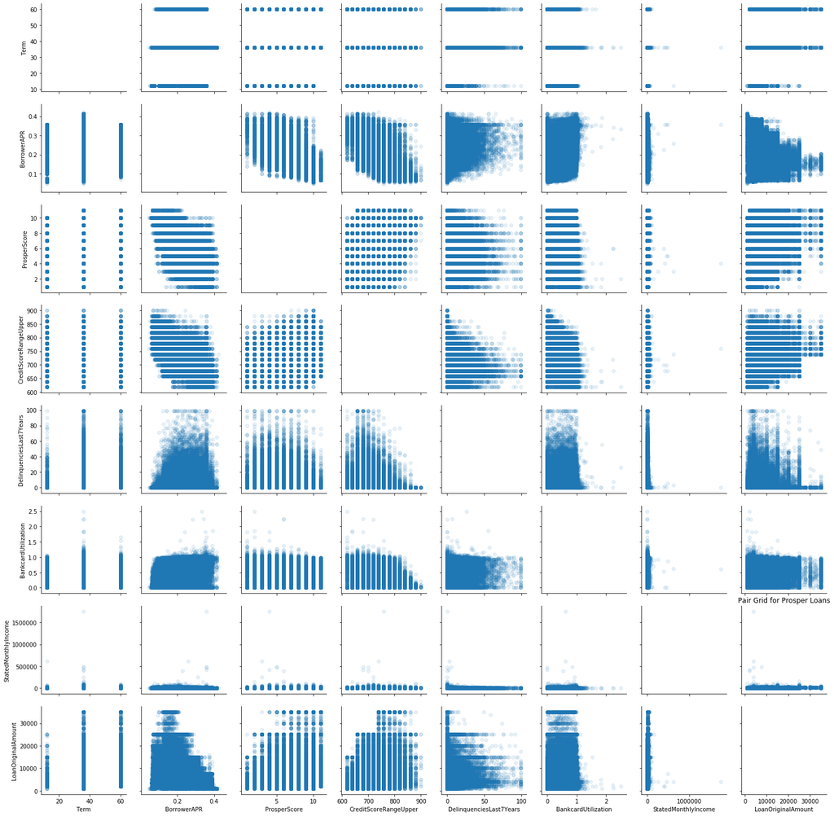

```python
#plot pairgrid of dataframe features
g = sb.PairGrid(data = df)
g.map_offdiag(plt.scatter, alpha=.1);
plt.title('Pair Grid for Prosper Loans');
```

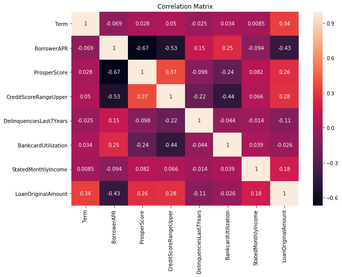

```python
# plot correlation matrix
plt.figure(figsize = [10, 7])
sb.heatmap(df.corr(),annot=True);
plt.title('Correlation Matrix');
```

### Did you observe any interesting relationships between the other features (not the main feature(s) of interest)?

- DelinquenciesLast7Years is less correlated with BorrowerAPR than I expected. However, since most borrowers had no delinquencies this isn't that surprising
- Term of the loan appears to be correlated with LoanOriginalAmount. Larger loan amounts tend to have longer loan terms, which also intuitively makes sense as the borrower would need more time to repay a larger loan

## Multivariate Exploration

Do we see any patterns in ProsperScore and BorrowerAPR across LoanStatus? In particular, do we see any trends among loans that defaulted? The following charts will help us answer these questions.

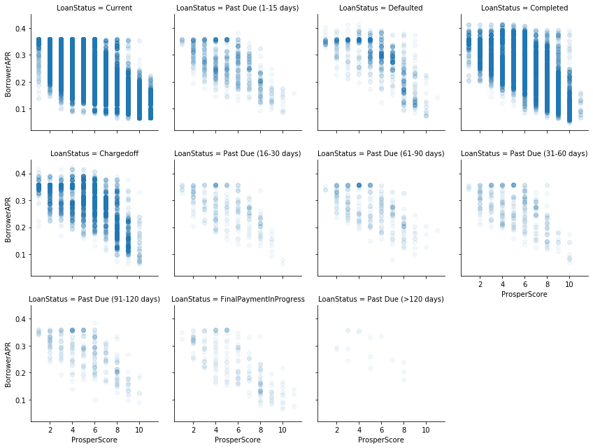

```python
#plot ProsperScore and BorrowerAPR by LoanStatus
g = sb.FacetGrid(data = df, col = 'LoanStatus', col_wrap = 4)
g.map(plt.scatter, 'ProsperScore', 'BorrowerAPR', alpha = 0.05);
```

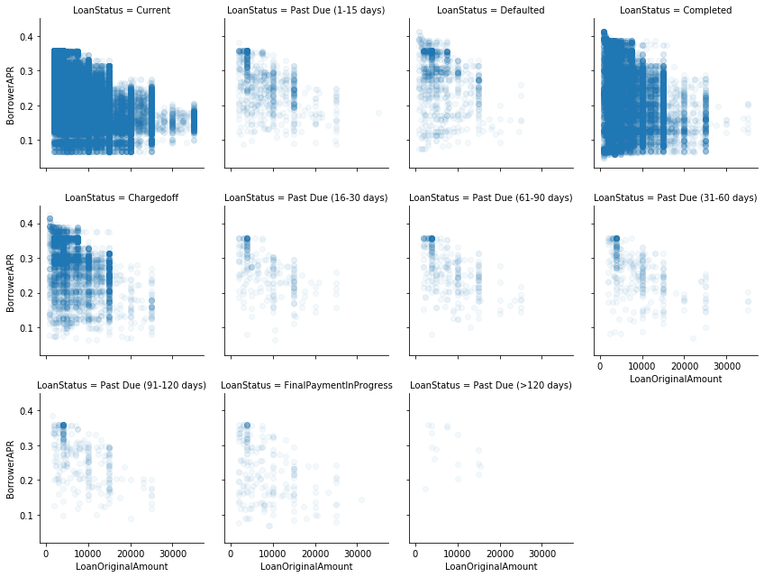

```python
#plot LoanOriginalAmount and BorrowerAPR by LoanStatus
g = sb.FacetGrid(data = df, col = 'LoanStatus', col_wrap = 4)
g.map(plt.scatter, 'LoanOriginalAmount', 'BorrowerAPR', alpha = 0.05);
```

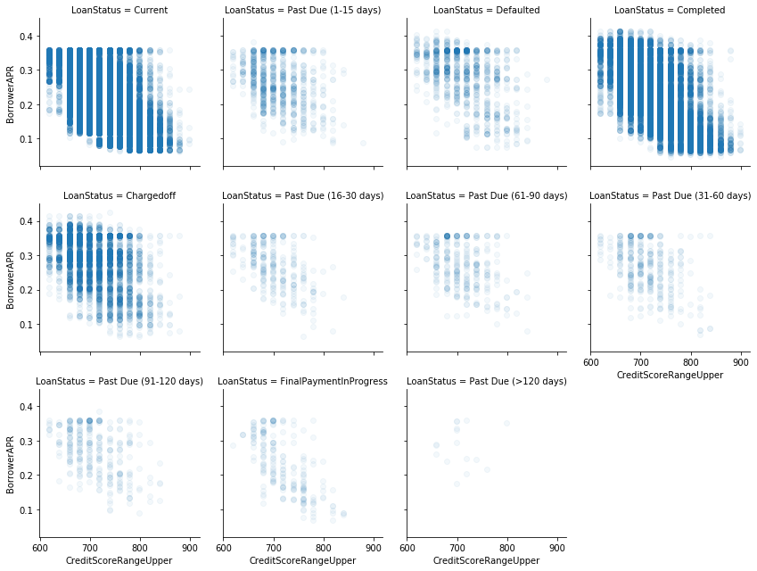

```python
#plot CreditScoreRangeUpper and BorrowerAPR by LoanStatus
g = sb.FacetGrid(data = df, col = 'LoanStatus', col_wrap = 4)
g.map(plt.scatter, 'CreditScoreRangeUpper', 'BorrowerAPR', alpha = 0.05);
```

### Talk about some of the relationships you observed in this part of the investigation. Were there features that strengthened each other in terms of looking at your feature(s) of interest?

I chose to use faceting to plot small multiples highlighting relationships between three features of interest at a time. I used a light shading (alpha 0.05) in order to better highlight areas of overlapping points.

- There were loans that defaulted across all levels of ProsperScore, but mostly concentrated in the mid to lower scores, indicating these borrowers were paying a higher APR to compensate for the higher likelihood of default. This trend suggests the ProsperScore is correctly identifying riskier borrowers and offering them higher APR.
- Defaults appear to be most common among smaller loan amounts
- The borrowers that defaulted had lower credit scores, as well (CreditScoreRangeUpper)

### Were there any interesting or surprising interactions between features?

- Looking at the Current loans, it appears the lowest BorrowerAPR isn't offered for the largest loans. I would have thought at least a few borrowers with a low risk profile would be offered the lowest BorrowerAPR for larger loans.